# Midterm Project

Ting Ho Marcus Cheung

March 10, 2024

## Introduction

Most Canadian cities are very car-centric, which means that personal vehicles are necessities and core of day to day life. Ever since the global pandemic in 2020, the economy has been performing poorly throughout the continent: low economic growth, high inflation, and layoffs have been the norm for the past 4 years. Since cars are vital for day to day life here and are an expensive purchase, purchasing brand new vehicles have become out of reach for most people. Thus, the question arises:

How do we predict used car prices based on their year of production, body type, brand/model, engine displacement, drivetrain, and odometer kilometers?

Specifically, I want to find out the speed of depreciation on vehicles with time together with other factors. I believe answering this question will allow me to find the best time to purchase a used vehicle, find the most reliable (depreciation rate wise) vehicle, and evaluate the different aspects that affect prices of cars to make the best decisions financially. Lastly, by building a model of pricing with these factors, I can potentially help car sellers settle down with a price to sell their cars.

## Method

To answer this question, I will use a dataset I found of Kaggle: “Used cars listings for US & Canada” and use only the dataset for Canada. The link is attached to the bottom of this report. The dataset contains data of online listing of cars from that were manufactured in 1981 to 2022. As stated on Kaggle, “Individual listing records show year, make, model and trim, with VIN-level histories, showing the most recent time the car showed up online back to the earliest, with every change that occurred over that time”. Furthermore, the dataset is collected across 8 years, where the latest was collected in 2022, which means that the first data was collected around 2014, which means that a car manufactured in 2013 might not be 9 years old when it was included in the dataset. Therefore, when looking at depreciation, I will strictly look at cars that appeared more than once. After exploring trends and building appropriate models using the data, I will parse through Autotrader to get come current listings to test the accuracy of the conclusion drawn from the Kaggle dataset.

# Data exploration

I downloaded the data from kaggle and loaded it into an RMD file and stored it in the variable “canada_data”. After running some summary functions such as ls, head, tail and nrow , I found that the earliest car ever produced was in 1981 and the latest was in 2022. The data has the 21 following variables, which are “body_type”, “city”, “drivetrain”, “engine_block”, “engine_size”, “fuel_type”, “id”, “make”, “miles”, “model”, “price”, “seller_name”, “state”, “stock_no”, “street”, “transmission”, “trim”, vehicle_type”, “vin”, “year”, and “zip”. The variable names are very self explainatory except id, which is a unique identifier for the listing. I did find some problems, that I will need to address in the data cleaning and wrangling process. There are a total of 393603 rows in the data.

```
## [1] 1981
```

```
## [1] 2022
```

```
##  [1] "body_type"    "city"         "drivetrain"   "engine_block" "engine_size"
##  [6] "fuel_type"    "id"           "make"         "miles"        "model"
## [11] "price"        "seller_name"  "state"        "stock_no"     "street"
## [16] "transmission" "trim"         "vehicle_type" "vin"          "year"
## [21] "zip"
```

```
## [1] 393603
```

|  | id | vin | price | miles | stock_no | year | make | model | trim | body_type | vehicle_type | drivetrain | transmission | fuel_type | engine_size | engine_block | seller_name | street | city | state | zip |
| --- | --- | --- | --- | --- | --- | --- | --- | --- | --- | --- | --- | --- | --- | --- | --- | --- | --- | --- | --- | --- | --- |
| 1 | b39ea795-eca9 | 19UNC1B01HY800062 | 179999 | 9966 | V-P4139 | 2017 | Acura | NSX | Base | Coupe | Car | 4WD | Automatic | Electric / Premium Unleaded | 3.5 | V | edmundston honda | 475 Rue Victoria | Edmundston | NB | E3V 2K7 |
| 2 | 026cb5b1-6e3e | 19UNC1B02HY800023 | 179995 | 5988 | PPAP70374 | 2017 | Acura | NSX | Base | Coupe | Car | 4WD | Automatic | Electric / Premium Unleaded | 3.5 | V | garage daniel lessard | 2795 Route-du-prsident-kennedy | Notre-dame-des-pins | QC | G0M 1K0 |
| 3 | 5cd5d5b2-5cc2 | 19UNC1B02HY800071 | 168528 | 24242 | B21085 | 2017 | Acura | NSX | Base | Coupe | Car | 4WD | Automatic | Electric / Premium Unleaded | 3.5 | V | lougheed acura | 1388 Lougheed Highway | Coquitlam | BC | V3K 6S4 |
| 4 | b32473ed-5922 | 19UNC1B02LY800001 | 220000 | 6637 | AP5333 | 2020 | Acura | NSX | Base | Coupe | Car | 4WD | Automatic | Electric / Premium Unleaded | 3.5 | V | drive autogroup | 1305 Parkway Suite 600 | Pickering | ON | L1V 3P2 |
| 5 | ac40c9fc-0676 | 19UNC1B02LY800001 | 220000 | 6637 | AP5333 | 2020 | Acura | NSX | Base | Coupe | Car | 4WD | Automatic | Electric / Premium Unleaded | 3.5 | V | acura pickering | 575 Kingston Road | Pickering | ON | L1V 3N7 |
| 6 | 0487af07-893c | 19UNC1B03HY800063 | 155771 | 18281 | U02856 | 2017 | Acura | NSX | Base | Coupe | Car | 4WD | Automatic | Electric / Premium Unleaded | 3.5 | V | gravel auto crdit | 102-1007 Boulevard Ren Lvesque Verdun | Montral | QC | H3E 0H1 |

| id | vin | price | miles | stock_no | year | make | model | trim | body_type | vehicle_type | drivetrain | transmission | fuel_type | engine_size | engine_block | seller_name | street | city | state | zip |
| --- | --- | --- | --- | --- | --- | --- | --- | --- | --- | --- | --- | --- | --- | --- | --- | --- | --- | --- | --- | --- |
| 008de9d9-89cf | 1B6MD3459JS650985 | 6995 | 23204 | 9241A | 1988 | Dodge |  | 350 |  |  |  |  |  | NA |  | midway motors ltd | Port Hastings | Port Hawkesbury | NS | B0E 1B0 |
| b4c0e182-5b57 | 1C3BG64JXKG258695 | NA | 68931 | U14-14 | 1989 | Chrysler |  | Daytona |  |  |  |  |  | NA |  | mazzuca chrysler | 331 Hanna Street | Capreol | ON | P0M 1H0 |
| 473cead8-08b7 | 1FDKE30L5FHB15219 | 5797 | 58000 |  | 1985 | Ford |  | 350 |  |  |  | Automatic |  | NA |  | logan lake auto sales | 115 Apex Drive | Logan Lake | BC | V0K 1W0 |
| dfe9116a-da1c | 1FMEU15H2FLA06335 | 15995 | 137000 | A06335 | 1985 | Ford |  | Custom |  |  | 4WD | Automatic |  | NA |  | 306 deal | 1104 22 Street West | Saskatoon | SK | S7M 0S5 |
| e588d632-c0c9 | 1FMEU15H6KLB11289 | 49000 | 64494 | P22016 | 1989 | Ford |  |  |  |  |  | Automatic |  | NA |  | trader demo ford | 12 Carrier Drive, Etobicoke | Toronto | ON | M9V 2C1 |
| c2ded3c3-cfae | 1FMEU15H6KLB11289 | 49000 | 64494 | P22016 | 1989 | Ford |  |  |  |  |  | Automatic |  | NA |  | southlake ford lincoln | 18001 Leslie Street | Newmarket | ON | L3Y 9A4 |
| 837389d9-fae4 | 1G1AP87L1BL157285 | 25995 | NA |  | 1981 | Buick | Camaro | LTD |  |  |  |  |  | NA |  | zimmer wheaton gmc buick | 685 Notre Dame Drive | Kamloops | BC | V2C 5N7 |
| 23b5477b-f4c9 | 1G1AP87L1BN139809 | 19900 | 93581 | R81-139809 | 1981 | Chevrolet | Camaro | Coupe |  |  | RWD | Automatic |  | NA |  | carson exports | 550 Windmill Road | Dartmouth | NS | B3B 1B3 |
| e946e6fd-99f9 | 1G1AZ37H3ER140773 | 7900 | 96246 |  | 1984 | Chevrolet | Monte Carlo |  |  |  |  | Automatic |  | NA |  | logan lake auto sales | 115 Apex Drive | Logan Lake | BC | V0K 1W0 |
| 55cf906a-2288 | 1G1FP31E6JL153766 | 14995 | 69021 | 23604 | 1988 | Chevrolet | Convertible |  | Convertible |  | RWD | Manual |  | NA |  | sk automarket sales ltd | 19833 Fraser Highway | Langley City | BC | V3A 4E1 |

[output cut: 90 more lines]

| id | vin | price | miles | stock_no | year | make | model | trim | body_type | vehicle_type | drivetrain | transmission | fuel_type | engine_size | engine_block | seller_name | street | city | state | zip |
| --- | --- | --- | --- | --- | --- | --- | --- | --- | --- | --- | --- | --- | --- | --- | --- | --- | --- | --- | --- | --- |
| 837389d9-fae4 | 1G1AP87L1BL157285 | 25995 | NA |  | 1981 | Buick | Camaro | LTD |  |  |  |  |  | NA |  | zimmer wheaton gmc buick | 685 Notre Dame Drive | Kamloops | BC | V2C 5N7 |
| 23b5477b-f4c9 | 1G1AP87L1BN139809 | 19900 | 93581 | R81-139809 | 1981 | Chevrolet | Camaro | Coupe |  |  | RWD | Automatic |  | NA |  | carson exports | 550 Windmill Road | Dartmouth | NS | B3B 1B3 |
| f59741ef-44e8 | WP0JA0934BS050051 | 120000 | 141004 | PORS-50051 | 1981 | Porsche | Turbo |  |  |  | RWD | Manual |  | NA |  | bulletproof auto sales | 12993 Steeles Avenue | Hornby | ON | L0P 1E0 |

# Data Cleaning and Wrangling

After that, I found some problems with the data as there are vehicles listed more than once in the dataset on the same year, same price, same mileage, but different dealers. For example, the 4th and 5th entry are both the same Acura NSX listed in Drive Autogroup and Acura Pickering. Therefore, I kept only 1 listing of the same vehicle (vin) at he same price and miles by using the distinct function.

Because I’m only interested in a selected few variables, I only kept the selected variables:

- vin
- price
- miles (is actually in kms since its Canada)
- year
- make
- model
- body_type
- drivetrain
- engine_size
- fuel_type

After performing further tests and checks for anomalies in the data, I found that many rows have missing data and they are represented as NA. Since I have large amounts of data, I removed all rows with NA. After this, there are only 157793 entries left.

Here is a sneak peak of the cleaned data

| vin | price | miles | year | make | model | body_type | drivetrain | engine_size | fuel_type |
| --- | --- | --- | --- | --- | --- | --- | --- | --- | --- |
| 19UNC1B01HY800062 | 179999 | 9966 | 12 | Acura | NSX | Coupe | 4WD | 3.5 | Electric / Premium Unleaded |
| 19UNC1B02HY800023 | 179995 | 5988 | 12 | Acura | NSX | Coupe | 4WD | 3.5 | Electric / Premium Unleaded |
| 19UNC1B02HY800071 | 168528 | 24242 | 12 | Acura | NSX | Coupe | 4WD | 3.5 | Electric / Premium Unleaded |
| 19UNC1B02LY800001 | 220000 | 6637 | 15 | Acura | NSX | Coupe | 4WD | 3.5 | Electric / Premium Unleaded |
| 19UNC1B03HY800063 | 155771 | 18281 | 12 | Acura | NSX | Coupe | 4WD | 3.5 | Electric / Premium Unleaded |
| 19UNC1B03HY800080 | 169998 | 17207 | 12 | Acura | NSX | Coupe | 4WD | 3.5 | Electric / Premium Unleaded |

| vin | price | miles | year | make | model | body_type | drivetrain | engine_size | fuel_type |
| --- | --- | --- | --- | --- | --- | --- | --- | --- | --- |
| 1FTFX1E51JFA82075 | 37870 | 53979 | 13 | Ford | F-150 | Pickup | 4WD | 5.0 | Unleaded / Unleaded |
| 1FTFX1E51JFA82075 | 37880 | 53978 | 13 | Ford | F-150 | Pickup | 4WD | 5.0 | Unleaded / Unleaded |
| 1FTPW14V58FA47462 | 10999 | 266000 | 3 | Ford | F-150 | Pickup | 4WD | 5.4 | E85 |
| 1FTPW14V58FA47462 | 10999 | 267000 | 3 | Ford | F-150 | Pickup | 4WD | 5.4 | E85 |
| 1G1RA6S52HU156957 | 9118 | 91120 | 12 | Chevrolet | Volt | Hatchback | FWD | 1.5 | Electric / Premium Unleaded |
| 1G1RA6S52HU156957 | 19981 | 90000 | 12 | Chevrolet | Volt | Hatchback | FWD | 1.5 | Electric / Premium Unleaded |

# Data distribution

I will plot some graphs to figure out the distribution of my cleaned data first.

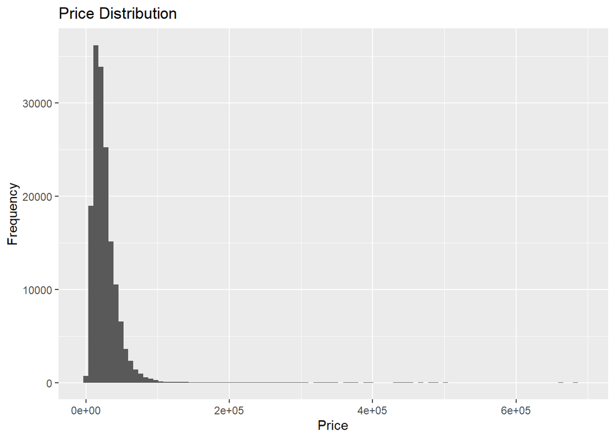

As shown in the price distribution histogram, as expected, most cars fall in between 0 to 100,000 dollar range. Specifically, between 10,000 to 40,000 CAD.

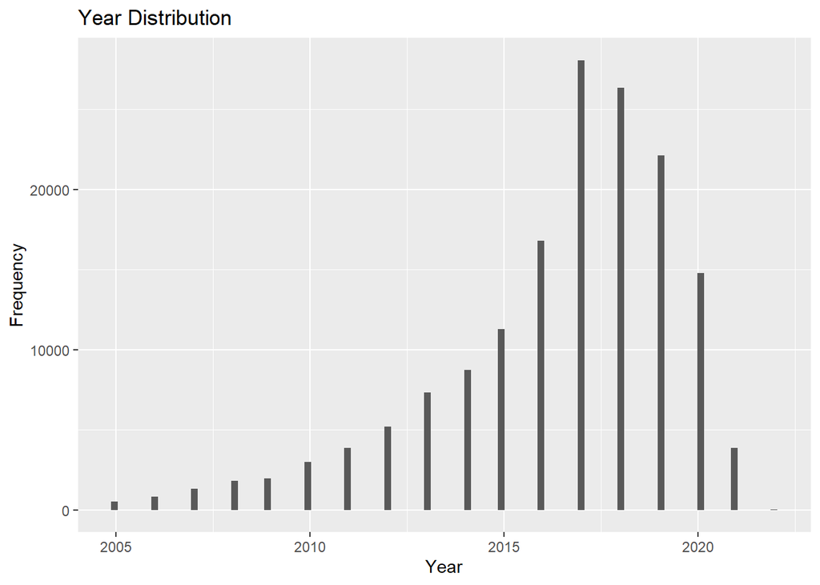

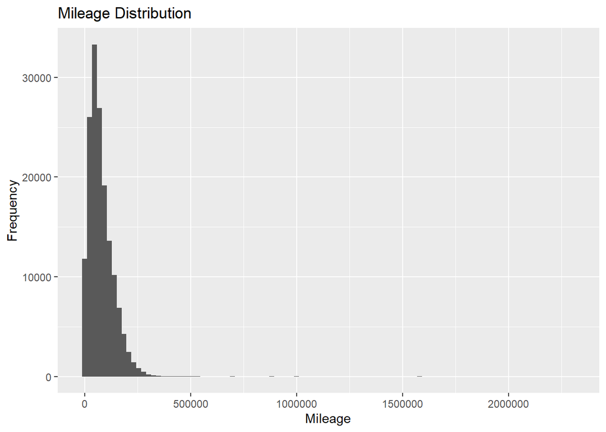

As shown, most of the cars have low mileage.

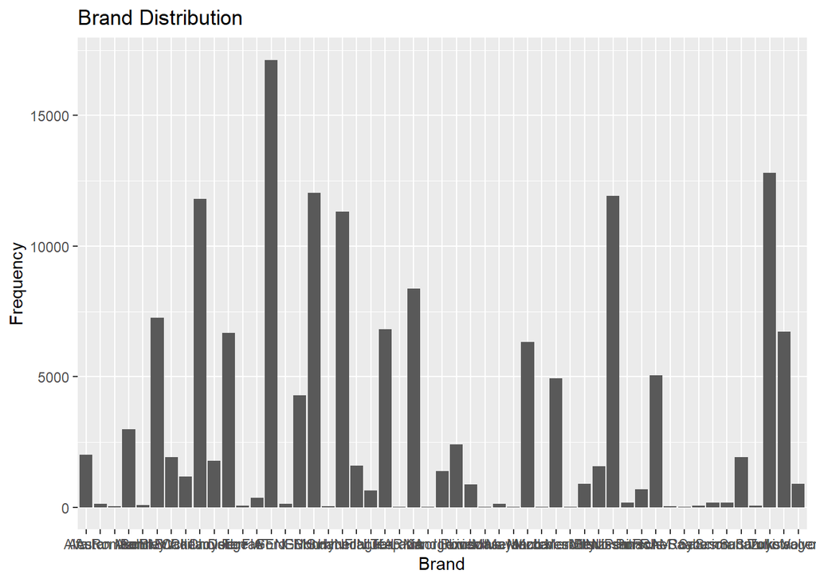

There are many brands, but only around 15 of them have decent quantity.

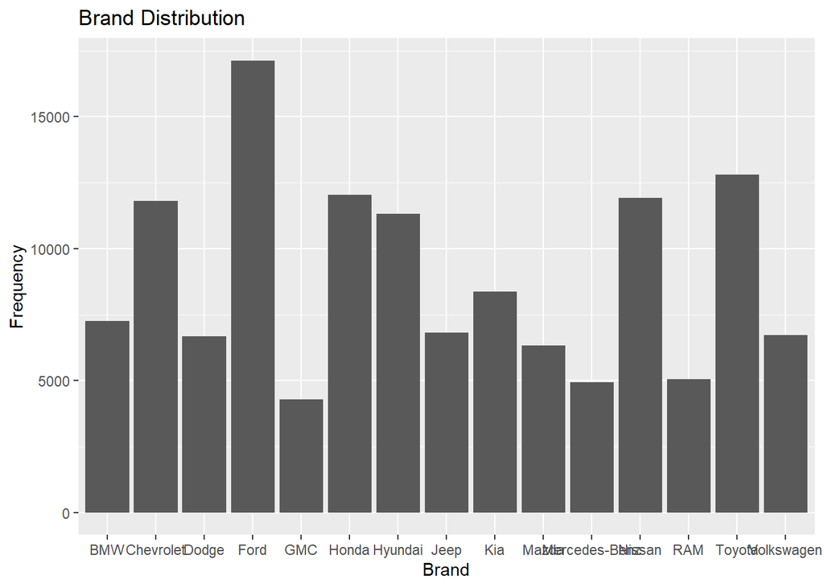

As shown in the brand bar graph, these are the most popular 15 brands. Unsurprisingly, Ford is the most popular brand.

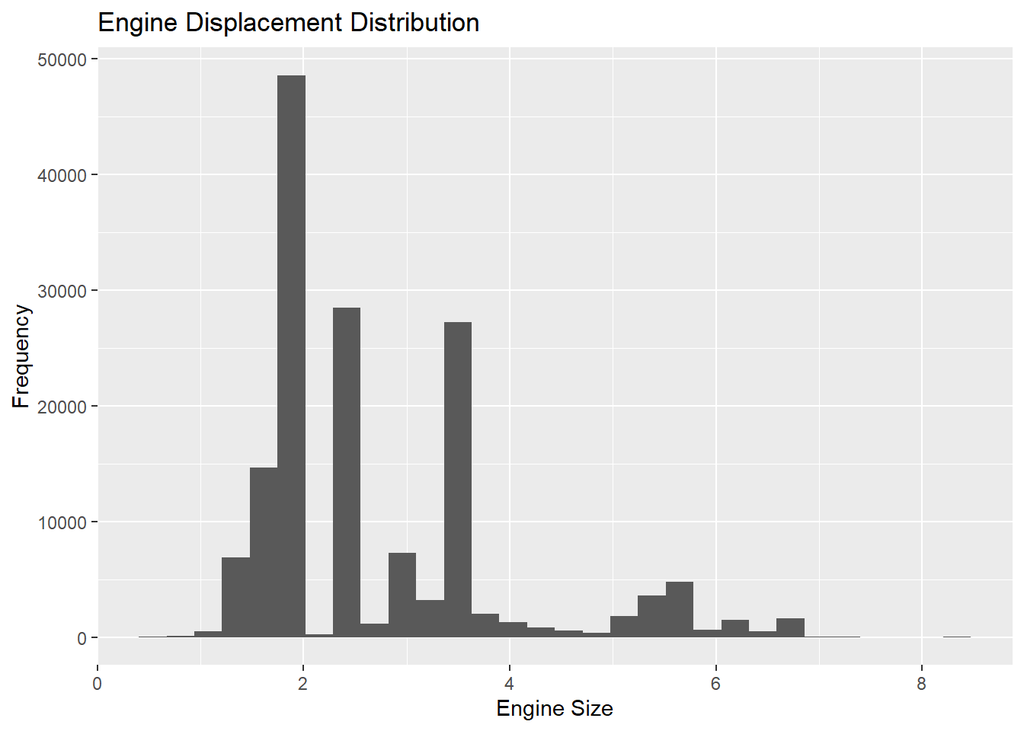

As shown in histogram, the most frequent engine size is around 2, this could be because 2 liter engines are exceedingly popular nowadays.

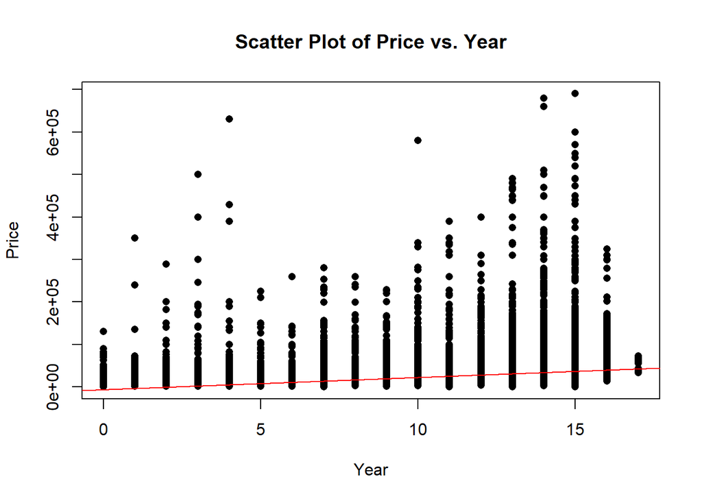

As shown from the red line, there is a trend that price increases as the model gets newer. This is expected because of depreciation of old cars and inflation in cost of things.

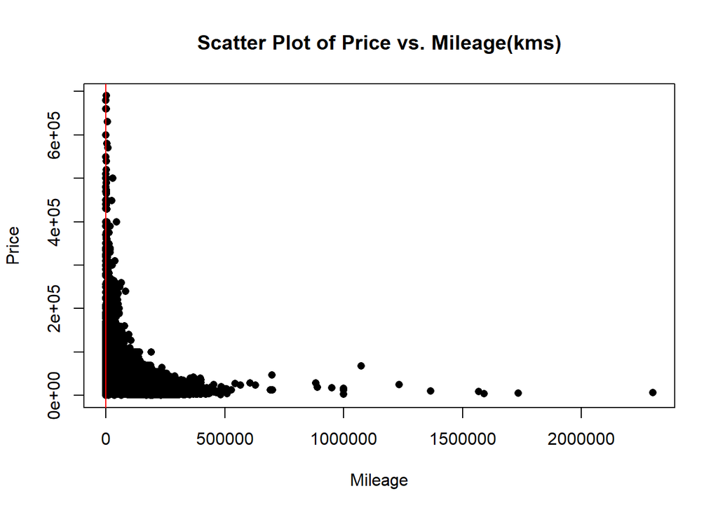

There is a strong negative relationship betwewen miles and price as shown in the scatterplot. This is intuitive because cars depreciate the more you drive them.

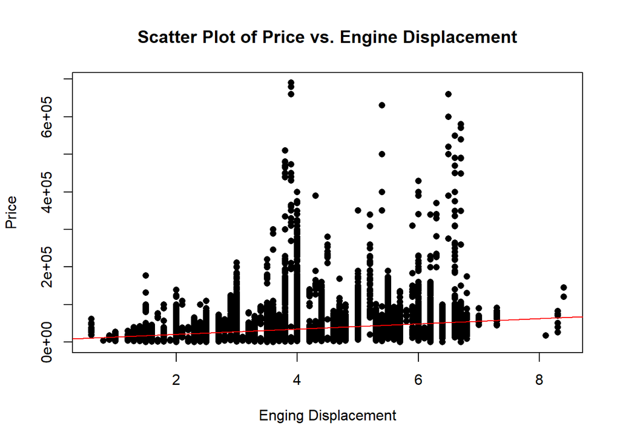

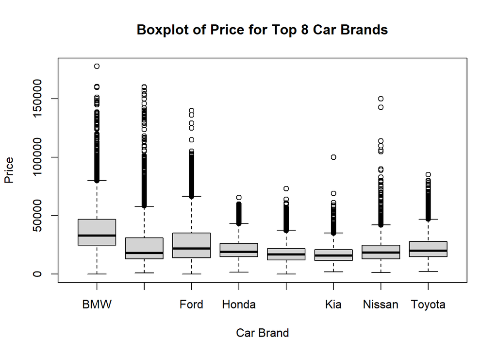

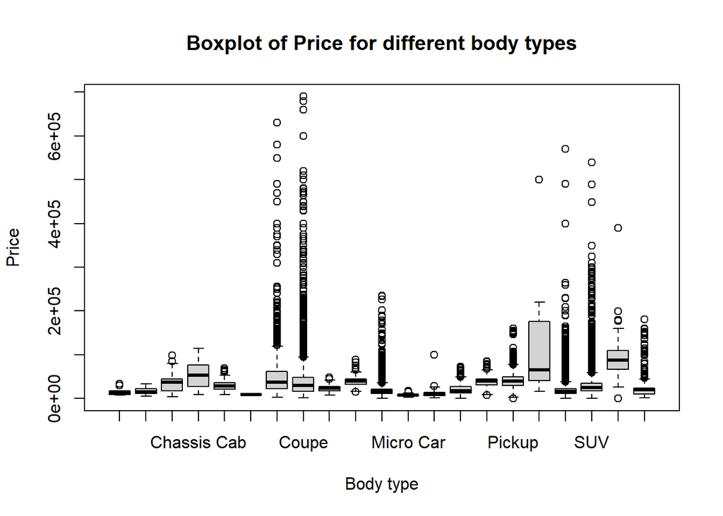

As shown in the boxplot above, different body types correspond to different price ranges.

[figure not shown]

# Summary

I have found substantial support that there is correlation between different factors of a car and its listed price, which in turns mean I may be able to build a model to predict the price based on other information given.

However, there are some problems already identified in my midterm report.

Lastly, there may be multicollinearity and confounding in the variables. For example, year definitely affects mileage and brand affects engine displacement (luxury brands usually have bigger engines by intuition ).

In the final report, I will aim to address the above issues stated to formulate a good and precise model. After that, I will use a web scraper to scrape some data from autotrader.ca and use the data to test the accuracy of my model and answer the problem “How do we predict used car prices based on their year of production, body type, brand/model, engine displacement, drivetrain, and odometer kilometers?”.

# Data

data: https://www.kaggle.com/datasets/rupeshraundal/marketcheck-automotive-data-us-canada